# Trees in Space

According to classic branching brownian motion, we have particles which branch at a constant rate (1) and move according to independent random walks in x and y dimensions $x_t,y_t \sim N(0,t)$. However, we need to adjust the branch lengths of this process. With this constant rate, $T_k \sim \sum^k_{i=1}{exp(1)}=exp(k)$. In a coalescent tree, then $T_k \sim exp(^kC_2)$.

Let’s illustrate this.

```r
devtools::load_all()
```

```
ℹ Loading treesinspace
```

```r
library(tidyverse)
library(ape)
library(sf)
library(MetBrewer)
library(ggrepel)
library(ggpubr)
library(ggtree)
library(moments)
library(phangorn)
library(apTreeshape)
devtools::load_all("~/slendr")
```

```
ℹ Loading slendr
```

```r
setup_env()
```

```
The interface to the required Python modules is now activated.
```

```r
check_env()
```

```
Summary of the currently active Python environment:

Python binary: /Users/mariadaria/Library/r-miniconda/envs/automatic_slendr_python_env/bin/python
Python version: 3.8.12 | packaged by conda-forge | (default, Jan 30 2022, 23:36:06)  [Clang 11.1.0 ]

slendr requirements:
 - tskit: version 0.4.1 ✓
 - msprime: version 1.1.0 ✓
 - pyslim: version 0.700 ✓
```

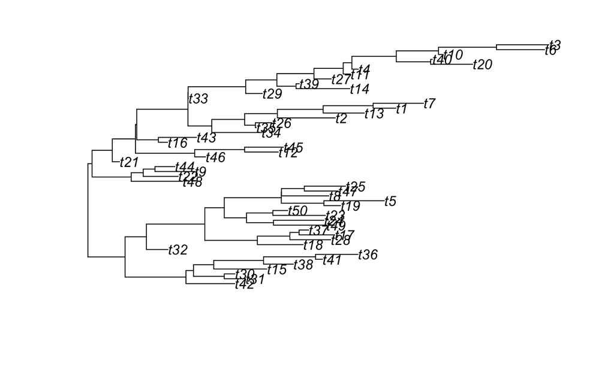

```r
# let's generate a random tree with 100 tips
n <- 50
tr <- rtree(n,equiprob = TRUE)
# and let's have a look at it
plot(tr)
```

Now, we can adjust the branch lengths to generate a coalescent-looking tree.

[figure not shown]

```r
# let's make an Ne which scales the rate of coalescence
Ne <- n
# edge_calculator takes the tree above with its topology, and sets branch lengths
tree <- edge_calculator(tr,
                        tree_mode = "coalescent", #stretches the edges so that T_n~exp(nC2)/2Ne
                        # if we had tree_mode = "brown", T_n~exp(1)
                        Ne=Ne) # (this is not needed if tree_mode="brown")
plot(tree) # now we see that the branch lengths are different and all the tips are in the present
nodelabels()
```

Now, I want to make these guys take a walk in space. So, I walk down the tree recursively, looking at each parent-child duo. Given a per-generation dispersal distance $d$, for each edge of length $t$, I draw displacements in x and y: $\delta x_t,\delta y_t \sim N(0,td)$. The root of the tree is placed at the origin, and descendants are scattered from their parents according to this displacement.

```r
tree_sim <- move_nodes(tree,disp_dist = 1)
nodes <- tree_sim$nodes # the node locations and times are stored in nodes.
# this is an sf object, which will allow us to do nice things downstream...
```

Could this have been generated by a Yule process?

” A simple model of speciation is to assume the exchangeability condition that, at any given time, each of the then-extant species are equally likely to give rise to one new species. The `rate’ of speciation may vary with time, or with the present and past number of species. Also we may allow extinctions or random sampling of extant taxa) provided that a similar exchangeability criterion applies ± that is, whenever an extinction event occurs each of the then-extant species is equally likely to go extinct.” - https://www.math.canterbury.ac.nz/~m.steel/Non_UC/files/research/shapepub.pdf

`rtree` is part of the ape package, and the algorithm behind it is described in https://rdrr.io/cran/ape/f/inst/doc/RandomTopologies.pdf

We can fit a Yule model to these trees, by the way.

```r
yule(rcoal(n, br = "coalescent"))
```

```
$lambda
[1] 9.455247

$se
[1] 0.9551242

$loglik
[1] 481.298

attr(,"class")
[1] "yule"
```

```r
yule(tree_sim)
```

```
$lambda
[1] 0.05263401

$se
[1] 0.005316838

$loglik
[1] -27.41629

attr(,"class")
[1] "yule"
```

```r
yule(tr)
```

```
$lambda
[1] 0.9896667

$se
[1] 0.09997143

$loglik
[1] 260.1163

attr(,"class")
[1] "yule"
```

We might also want to visualise the nodes.

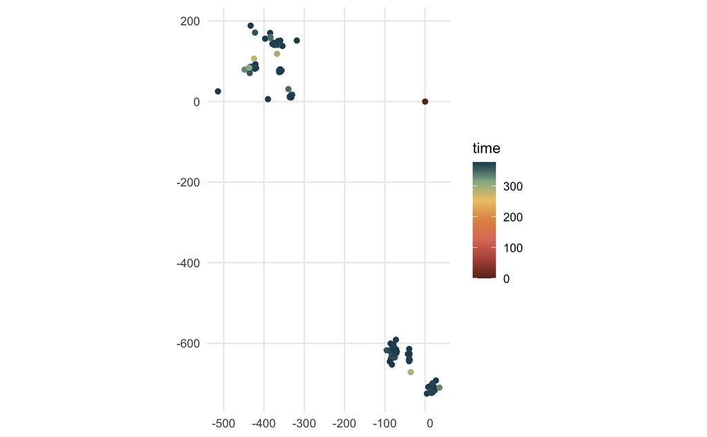

```r
ggplot(nodes) +
  geom_sf(aes(col=time)) +
  scale_color_gradientn(colors=met.brewer("Hokusai1")) +
  theme_minimal()
```

Since most of the edges are short and recent, we see that the nodes are clustered. We can actually do better with the visualisation though, and show branches and identities as well.

```r
links <- treesim_connect(tree_sim)[[1]]
```

```
Simple feature collection with 199 features and 4 fields
Geometry type: POINT
Dimension:     XY
Bounding box:  xmin: -514.4013 ymin: -724.7814 xmax: 35.62147 ymax: 188.4289
CRS:           NA
```

| node_id | time | x | y | location |
| --- | --- | --- | --- | --- |
| 1 | 376.9848 | 7.793561 | -708.504250 |  |
| 2 | 376.9848 | 12.262127 | -706.254480 |  |
| 3 | 376.9848 | 26.774622 | -692.262079 |  |
| 4 | 376.9848 | 4.446756 | -724.781351 |  |
| 5 | 376.9848 | 17.796398 | -717.983068 |  |
| 6 | 376.9848 | 22.308732 | -709.105023 |  |
| 7 | 376.9848 | 23.614566 | -716.945755 |  |
| 8 | 376.9848 | 15.795234 | -711.861965 |  |
| 9 | 376.9848 | -87.735592 | -645.322379 |  |
| 10 | 376.9848 | -77.660899 | -629.890170 |  |

[output cut: 189 more lines]

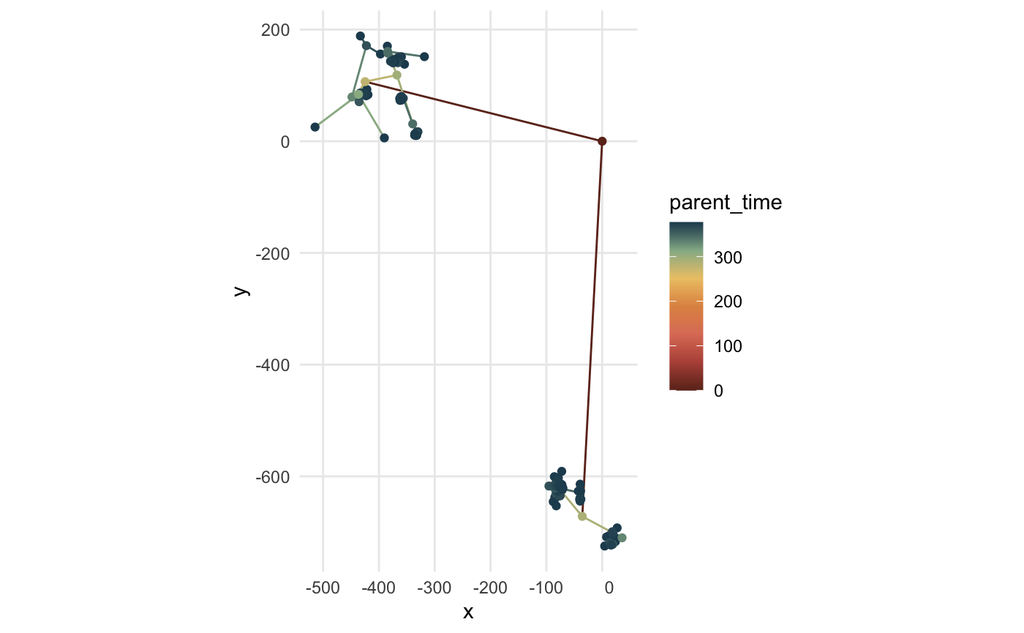

```r
ggplot(nodes) +
  scale_color_gradientn(colors=met.brewer("Hokusai1")) +
  geom_label_repel(aes(label=node_id,x=x,y=y))+
  geom_sf(data=links,aes(geometry=connection,col=parent_time)) +
  geom_sf(aes(col=time)) +
  theme_minimal()
```

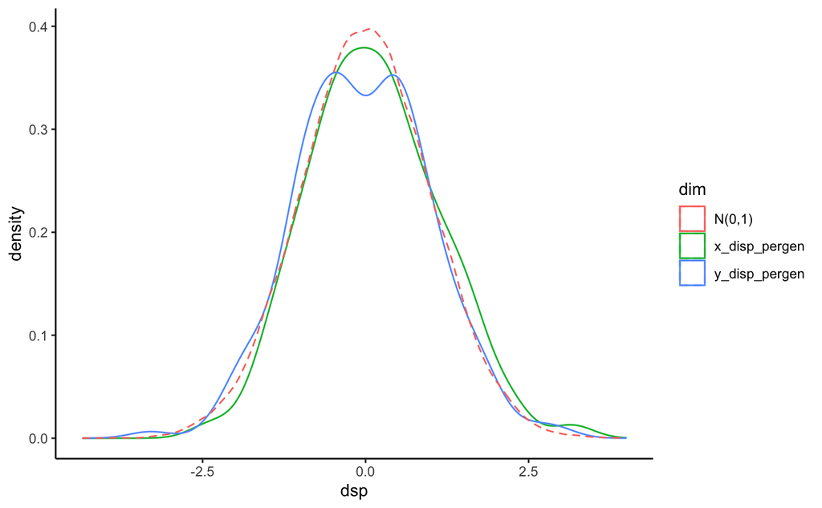

```r
# let's draw from a normal distribution to get the expected shape of the curve
normal <- data.frame(dsp=rnorm(50000,0,1))
# and now let's compare this to what happens in our tree
links %>%
  pivot_longer(cols = c("x_disp_pergen","y_disp_pergen"),
               names_to = "dim",
               values_to = "dsp") %>%
  ggplot(aes(x=dsp,col=dim))+
  geom_density()+
  geom_density(data=normal,
               aes(col="N(0,1)"),
               lty=2)+
  theme_classic()
```

Looks pretty good!

In this type of simulation, spatial similarity is very closely mirrored by genetic similarity. I can illustrate this by first performing a simple hierarchical clustering on the eucledian distance between points…

```r
pairs_sim <- find_ancestors(tree=tree_sim,data=tree_sim$nodes)
dmat_sim <- pairs_sim %>%
  mutate(distance=st_length(line)) %>%
  select(n1,n2,distance) %>%
  pivot_wider(names_from = n2,values_from = distance) %>%
  column_to_rownames("n1") %>% as.matrix()
dmat_sim[is.na(dmat_sim)==TRUE] <- 0
clust_sim <- hclust(as.dist(dmat_sim))
```

And plotting this tree compared to the true phylogeny….

```r
p1 <- ggtree(tree_sim)
p2 <- ggtree(clust_sim)
```

[output not shown]

### Simulating trees in slendr

Now, I want to simulate trees in slendR, and see how Brownian they look. I’ll first set out some parameters, which include: * the competition distance: in what radius and individual competes with its neighbours. This affects the fitness scaling of individuals (in crowded areas, fitness is scaled down). * the mating distance: how far can an individual look for a mate? In theory, fi we want this to be as Brownian as possible, this should be small. When children are generated in slim, a parent is randomly chosen as the mother and children are dispersed from this parent (we could change this also). If the mating distance is large, this might result in a surprisingly long edge, since a child may be dispersed very far from one of its parents (the one recorded in a particular tree). If this is too small, however, slim might crash because it will sometimes be unable to find a mate for an individual. * the dispersal function: determines how a child is thrown away from its mother. We currently have: * Uniform: choose an angle and a distance from the uniform distribution * Cauchy: choose an angle from a uniform distribution and a distance from a cauchy * Exponential: choose an angle from a uniform distribution and a distance from an exponential distribution * Normal: choose an angle from a uniform distribution and a distance from a normal distribution (mean 0, $\sigma^2$ equal to dispersal distance). *Note: this actually results in a Rayleigh distribution of distances from the mother!* * Brownian: draw distances in x and y independently from noormal distributions of mean 0, $\sigma^2$ dispersal distance.

```r
# defining parameters
Ns <- n
mat_dists <- c(20,50,Ns * 4) # mate distance
comp_dists <- c(0,10,50,Ns * 4) # competition distance
disp_dists <- 1 # mean dispersal distance
disp_funs <- c("brownian","normal","cauchy","uniform")
reps <- c(1:10)
ngens <- Ns * 4 # expected time to coalescence

# let's also make a parameter table
pars <- expand.grid(N=Ns,
                    mat_dist=mat_dists,
                    comp_dist=comp_dists,
                    disp_fun=disp_funs,
                    disp_dist=disp_dists,
                    rep=reps,
                    ngen=ngens)
```

Now, I run a series of simulations with these parameters.

```r
# defining a region
map <- world(
  # let's make this very large so that we avoid edge effects
  xrange = c(-ngens*4, ngens*4), # min-max longitude
  yrange = c(-ngens*4, ngens*4), # min-max latitude
  landscape = "blank"
)

# running the model
trees <- c()
trees_us <- c()
conns <- c()
i <- 1

for (row in c(1:dim(pars)[1])){

  # define a population
  pop <- population("POP",
                    time = 1,
                    N = pars[row,"N"],
                    center = c(0,0),
                    radius = ngens,
                    map = map,
                    mate_dist = pars[row,"mat_dist"],
                    competition_dist = pars[row,"comp_dist"],
                    dispersal_fun = as.character(pars[row,"disp_fun"]),
                    dispersal_dist = pars[row,"disp_dist"])

  # compile and run the model
  model <- compile(
    populations = pop,
    generation_time = 1,
    sim_length = ngens, # a forward in time model in slendr needs length of the sim
    resolution = 1, # resolution in "distance units per pixel"
    # how can we control this distribution?
    path = "~/Desktop/test-model",
    overwrite = TRUE
  )

  # let's sample 10 individuals in the "present"
  samples <- sampling(model, times = ngens, list(pop, n/2))

  # simulate
  slim(
    model, sampling = samples,
    sequence_length = 1,
    recombination_rate = 0, # simulate only a single locus
    method = "batch", # change to "gui" to execute the model in SLiMgui
    random_seed = 5*i,
    verbose = FALSE,
    retainall = TRUE,
    burnin = 0,
  )

  # extract trees
  ts <- ts_load(model, simplify = TRUE) %>%
    ts_recapitate(Ne = pars[row,"N"],
                  recombination_rate = 0) %>%
    ts_simplify() %>%
    ts_mutate(mutation_rate = 1e-4)

  # extract full genealogies trees
  tsu <- ts_load(model, simplify = FALSE)

  # collect trees
  trees <- c(trees,ts)
  trees_us <- c(trees_us,tsu)

  print(paste("Simulation number:",i))
  i <- i+1
}
```

```
[1] "Simulation number: 1"
[1] "Simulation number: 2"
[1] "Simulation number: 3"
[1] "Simulation number: 4"
[1] "Simulation number: 5"
[1] "Simulation number: 6"
[1] "Simulation number: 7"
[1] "Simulation number: 8"
[1] "Simulation number: 9"
[1] "Simulation number: 10"
[1] "Simulation number: 11"
[1] "Simulation number: 12"
[1] "Simulation number: 13"
[1] "Simulation number: 14"
[1] "Simulation number: 15"
```

[output cut: 401 more lines]

```r
tree_data <- tree_data %>%
  group_by(sim) %>%
  mutate(timeoriginal=time,time=timeoriginal-min(timeoriginal)) # adjust so that time starts at 0 (adjusting for recapitated trees)
# join dataframes
tree_sim_data <- tree_sim$nodes %>% mutate(simtype="tree")
tree_data_sims <- tree_data %>%
  mutate(simtype="slendr") %>%
  bind_rows(tree_sim_data)
```

[figure not shown]

```r
tree_data_sims %>% ggplot()+
  geom_sf(aes(col=fun,fill=fun))+
  facet_grid(cols=vars(comp_dist),rows=vars(mat_dist), labeller = label_both)+
  theme_minimal()
```

There’s an important point to think about here: *we cannot look at where the descendants are to when we simulate compared to the tree method to decide how brownian the process is*! With the tree method, we are effectively picking an ancestor, and looking at the tree with n descendants. They will be clustered. This is different to the slendr method, where we are sampling n tips randomly (scattered thorughout the landscape), and tracing back to a common ancestor! We can think of the tree model as more allele-centric: if the root had a new (neutral) mutation, carriers of this mutation are expected to be clustered! To get round this, we should be randomly picking a node at the start of the simulation and looking at the tree of its descendants.

But, this also means for us that eyeballing the spread of individuals won’t help. We need to look at the branch-wise dynamics.

We can also directly look at the steps between parent and offspring. Fortunately, I’ve saved the location of everyone in the tree in `trees_us`! Now, I can extract the connections between the nodes.

```r
conns <- lapply(trees_us,ts_connect)
```

```r
p_uns <- conns[[1]][[1]] %>%
  as.data.frame() %>%
  ggplot() +
  geom_sf(aes(geometry=connection,col=parent_time),alpha=0.2) +
  geom_sf(aes(geometry=parent_location,col=parent_time,shape="unsimplified"),alpha=0.5) +
  scale_color_gradientn(colors=met.brewer("Hokusai1"))

first_tree <- tree_data_sims %>% filter(sim==1)

p_uns +
  geom_sf(data=first_tree ,aes(geometry=location,col=timeoriginal,shape="simplified")) +
  scale_color_gradientn(colors=met.brewer("Hokusai1")) +
  theme_minimal()
```

[output not shown]

And again let’s check with the edges connecting two tips.

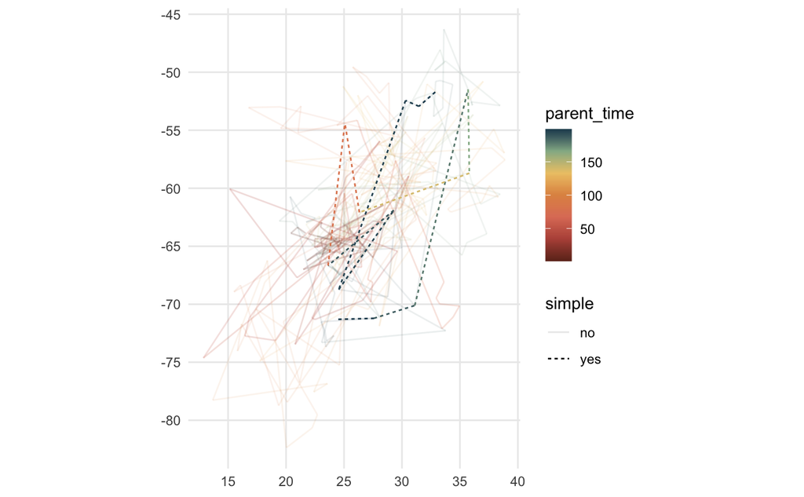

```r
walk <- ts_ancestors(ts=trees_us[[1]],x = c(1,2)) %>% mutate(simple="no") %>%
  rbind(mutate(ts_ancestors(ts=trees[[1]],x = c(1,2)),simple="yes"))

walk %>% ggplot(aes(col=parent_time,lty=simple,alpha=simple))+geom_sf(aes(geometry=connection)) +
  scale_color_gradientn(colors=met.brewer("Hokusai1")) +
  theme_minimal()
```

Let’s look at per-generation dispersal:

```r
ds <- data.frame()
for (sim in c(1:dim(pars)[1])){
  d <- conns[[sim]][[1]] %>% as.data.frame() %>% select(x_disp,y_disp,child_time) %>% cbind(pars[sim,])
  ds <- rbind(ds,d)
}
```

[output not shown]

[output cut: 305 more lines]

[output not shown]

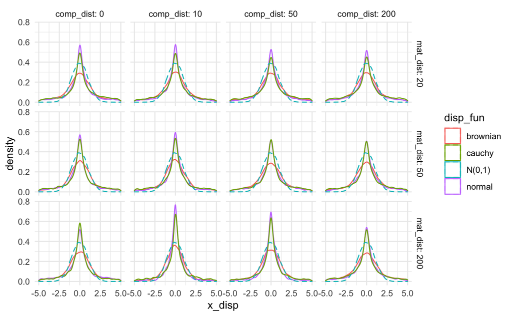

```r
ds %>% ggplot(aes(x=x_disp,col=disp_fun)) +
  geom_density(alpha=0.5) +
  facet_grid(cols=vars(comp_dist),rows=vars(mat_dist), labeller = label_both) +
  lims(x=c(-5,5)) +
  geom_density(data=normal,
               aes(col="N(0,1)",x=dsp),
               lty=2)+theme_minimal()
```

Let’s look at the kurtosis and some moments.

```r
dsm <- ds %>%
  group_by(mat_dist,comp_dist,disp_fun) %>%
  summarise(kurtosis=kurtosis(x_disp),variance=var(x_disp)) %>%
  pivot_longer(cols=c("kurtosis","variance"),names_to = "statistic",values_to="value")
```

[output not shown]

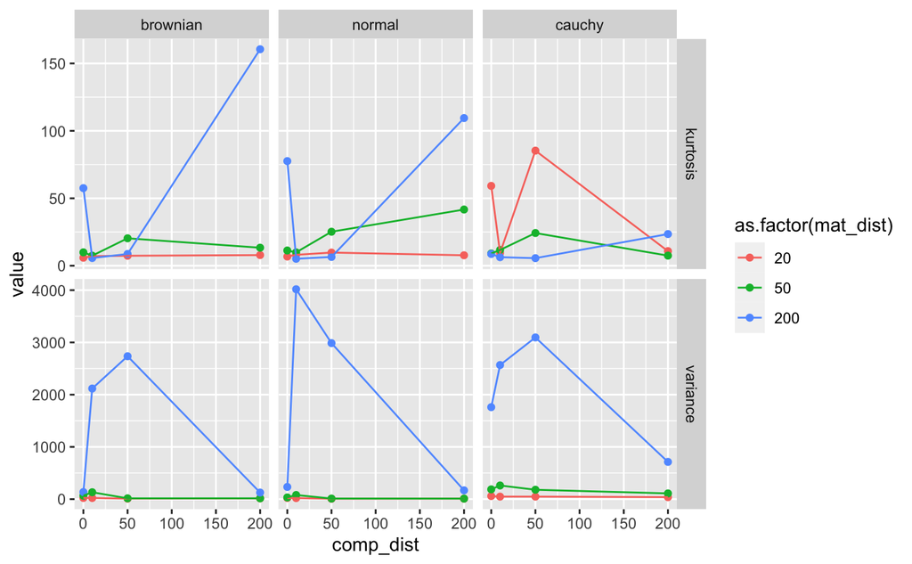

```r
dsm %>%
  ggplot(aes(x=comp_dist,y=value,col=as.factor(mat_dist))) +
  geom_point() +
  geom_line() +
  facet_grid(rows=vars(statistic),cols=vars(disp_fun),scales="free_y")
```

And let’s look at this over time.

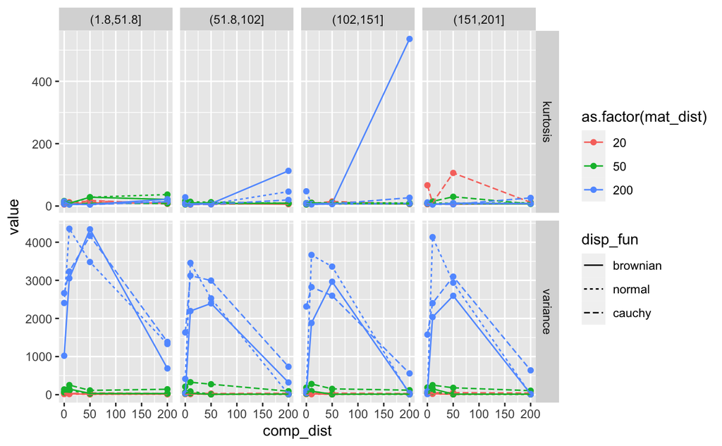

```r
dsmt <- ds %>% mutate(child_time=as.numeric(child_time),timegroup=cut(child_time,breaks = 4)) %>%
  group_by(mat_dist,comp_dist,disp_fun,timegroup) %>%
  summarise(kurtosis=kurtosis(x_disp),variance=var(x_disp)) %>%
  pivot_longer(cols=c("kurtosis","variance"),names_to = "statistic",values_to="value")
dsmt %>%
  ggplot(aes(x=comp_dist,y=value,col=as.factor(mat_dist),lty=disp_fun)) +
  geom_point() +
  geom_line() +
  facet_grid(rows=vars(statistic),cols=vars(timegroup),scales="free_y")
```

### How good are we at finding ancestors?

```r
ancs <- find_ancestors(tree=tree_sim,data=nodes)

p1 <- ancs %>% filter(MRCA==n+1|MRCA==91) %>% ggplot(aes(col=as.factor(MRCA))) +
  geom_sf(aes(geometry=MRCA_location,shape="true location")) +
  geom_sf(aes(geometry=midpoint,shape="estimated"),alpha=0.1) +
  geom_sf(aes(geometry=midtomrca,lty="error"),alpha=0.1)

p2 <- ancs %>% ggplot(aes(x=MRCA_time,y=error)) +
  geom_jitter(alpha=0.5,size=0.5,aes(col=as.factor(MRCA))) +
  geom_smooth(aes(group=MRCA_time))

ggarrange(p1,p2,common.legend = TRUE)
```

[output not shown]

```r
ancs <- find_ancestors(tree=ts_phylo(trees[[1]],i=1),data=filter(tree_data_sims,sim==1))

p1 <- ancs %>% filter(MRCA==n+1|MRCA==91) %>% ggplot(aes(col=as.factor(MRCA))) +
  geom_sf(aes(geometry=MRCA_location,shape="true location")) +
  geom_sf(aes(geometry=midpoint,shape="estimated"),alpha=0.1) +
  geom_sf(aes(geometry=midtomrca,lty="error"),alpha=0.1)

p2 <- ancs %>% ggplot(aes(x=MRCA_time,y=error)) +
  geom_jitter(alpha=0.5,size=0.5,aes(col=as.factor(MRCA)))

ggarrange(p1,p2,common.legend = TRUE)
```

[output not shown]

```r
ancs_all <- data.frame()
small_pars <- pars %>% filter(rep<3)
for (i in c(1:dim(small_pars)[1])){
  ancs_i <- find_ancestors(tree=trees_phylo[[i]],data=filter(tree_data_sims,sim==i)) %>% mutate(sim=i)
  ancs_all <- rbind(ancs_all,ancs_i)
}
```

Now we can explore this a bit more systematically.

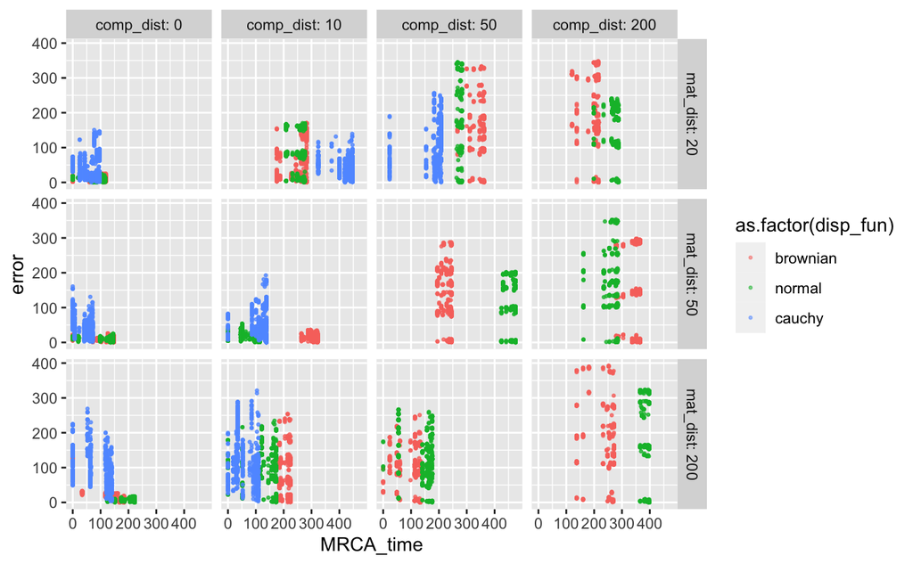

It’s kind of simple: the less a population spreads, the less wrong we are. With no particular relationship to the time of the MRCA.